# 1717719

dizhen

11/25/2019

### Step1. Data

```r
PH <- c(207, 221, 212, 220, 190, 172, 223, 260, 214, 245, 191, 181, 210, 215, 171, 221, 217, 265, 206, 261, 203, 208, 206, 247, 182, 241, 202, 198, 221, 162, 208, 218, 210, 199, 182, 199, 216, 211, 196, 225, 185, 168, 274, 239, 203, 235, 168, 223, 199, 195, 214, 214, 175, 244, 178, 134, 203, 203, 214, 240, 226, 280, 168, 236, 222, 222, 203, 178, 249, 117, 213, 225, 217, 212, 252, 272, 227, 200, 259, 203, 185, 239, 226, 189, 245, 181, 265, 207, 235, 218, 238, 228, 232, 239, 152, 141, 226, 182, 239, 231, 203, 236, 215, 210, 237, 222, 195, 239, 203, 221, 284, 210, 188, 180, 183, 207, 237, 276, 266, 224, 231, 226, 258, 251, 222, 224, 214, 212, 174, 206, 260, 201, 219)

NT <- c(286, 189, 226, 196, 187, 142, 204, 179, 203, 212, 206, 163, 196, 196, 168, 189, 229, 142, 184, 168, 186, 121, 281, 203, 177, 135, 179, 161, 194, 206, 219, 173, 189, 194, 196, 212, 168, 188, 232, 242, 200)
```

Visualise and summarize data

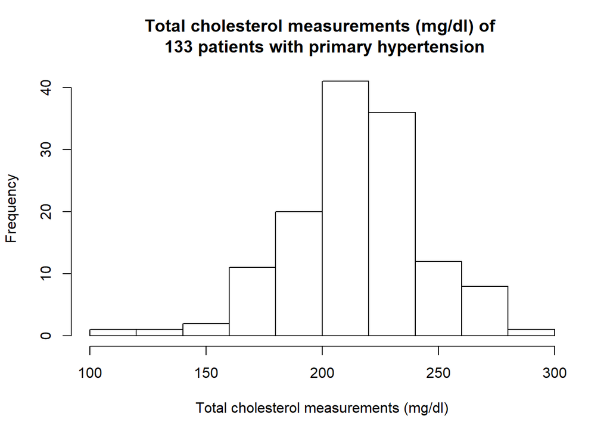

```r
hist(PH,
     xlab = "Total cholesterol measurements (mg/dl)",
     main = "Total cholesterol measurements (mg/dl) of \n 133 patients with primary hypertension")
```

```r
summary(PH)
```

```
##    Min. 1st Qu.  Median    Mean 3rd Qu.    Max.
##   117.0   199.0   214.0   214.7   235.0   284.0
```

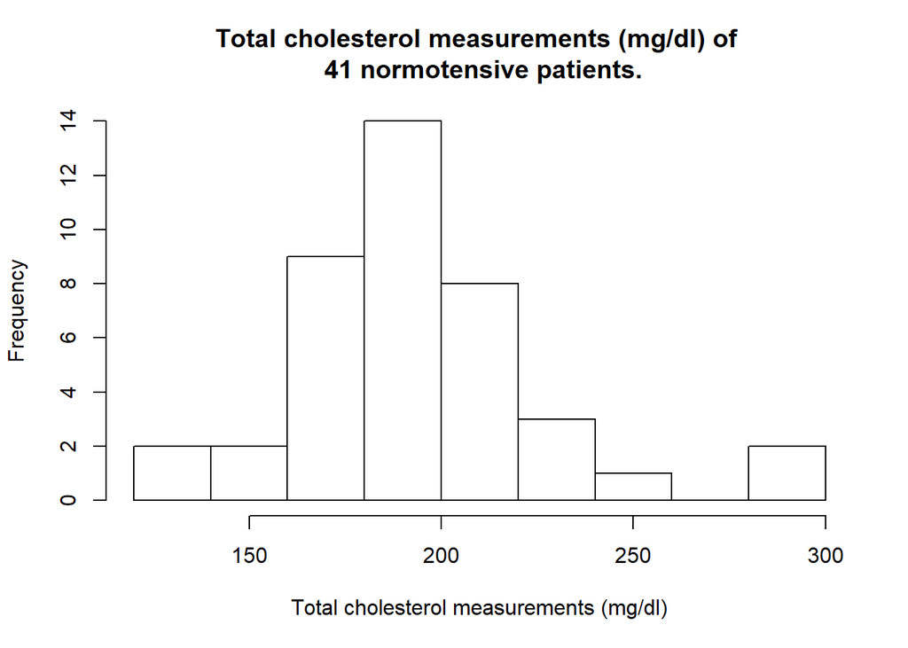

```r
hist(NT,
     xlab = "Total cholesterol measurements (mg/dl)",
     main = "Total cholesterol measurements (mg/dl) of \n 41 normotensive patients.")
```

```r
summary(NT)
```

```
##    Min. 1st Qu.  Median    Mean 3rd Qu.    Max.
##   121.0   177.0   194.0   193.2   206.0   286.0
```

```r
patients <- c(rep("PH", length(PH)))
total_cholesterol_measurments <- PH
df1 <- data.frame(patients, total_cholesterol_measurments)

patients <- c(rep("NT", length(NT)))
total_cholesterol_measurments <- NT
df2 <- data.frame(patients, total_cholesterol_measurments)

mydf <- rbind.data.frame(df1,df2)
```

```r
str(mydf)
```

```
## 'data.frame':    174 obs. of  2 variables:
##  $ patients                     : Factor w/ 2 levels "PH","NT": 1 1 1 1 1 1 1 1 1 1 ...
##  $ total_cholesterol_measurments: num  207 221 212 220 190 172 223 260 214 245 ...
```

```r
head(mydf)
```

```
##   patients total_cholesterol_measurments
## 1       PH                           207
## 2       PH                           221
## 3       PH                           212
## 4       PH                           220
## 5       PH                           190
## 6       PH                           172
```

A plot that compares the two total cholesterol measurements of the two groups

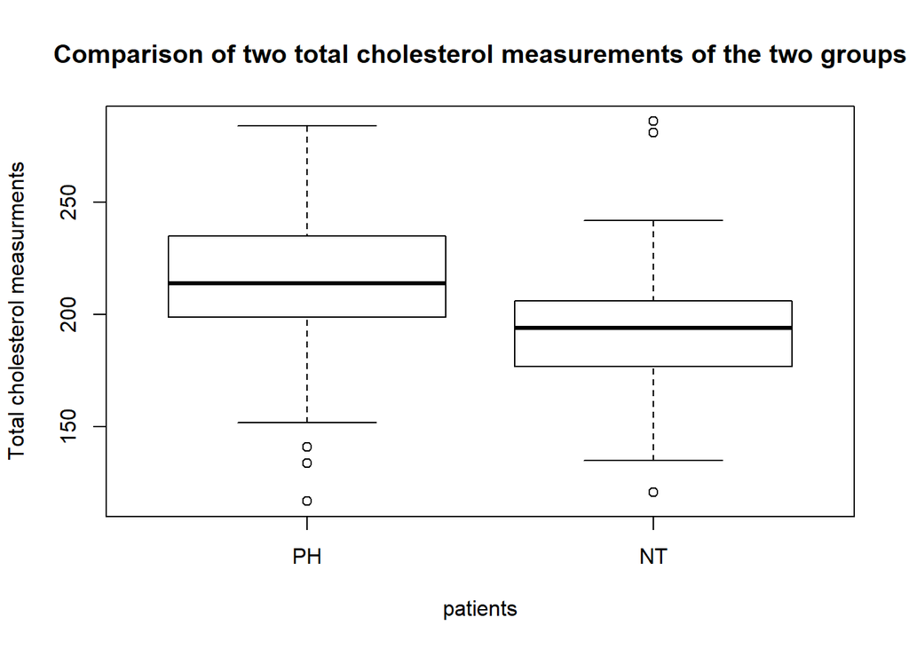

```r
boxplot(total_cholesterol_measurments ~ patients, data = mydf,
         main = "Comparison of two total cholesterol measurements of the two groups",
         ylab = "Total cholesterol measurments")
```

```r
with(mydf, rbind(MEAN<-tapply(total_cholesterol_measurments,patients,mean),
                 VAR<-tapply(total_cholesterol_measurments,patients,var)))
```

```
##            PH        NT
## [1,] 214.7143  193.1951
## [2,] 879.1602 1091.9610
```

Conclusion. There was no evidence of non-normality (boxplots not grossly asymmetrical) or unequal variance (boxplots very similar size and variances very similar). Hence, the simple, studentized (pooled variances) t-test is likely to be reliable.

### Step2. Assumptions

1. Both samples are simple random samples.
2. Two samples are independent, they are not matched or paired in any way.
3. Both sample sizes are large (n1>30 and n2>30)
4. Both population standard deviations $\sigma_1$ and $\sigma_2$ are unknown. All requirements are satisfied, we perform a two sample t test with equal variances.

### Step3. Hypothesis

Alternative hypothesis: The mean of total cholesterol levels of patients with primary hypertension (PH) $\bar{x_1}$ is higher than it of normotensive (NT) patients $\bar{x_2}$.

$$H_0: \bar{x_1} \leqslant \bar{x_2}\\
H_A: \bar{x_1} > \bar{x_2}$$

### Step4. Test Statistic

We consider the population variances are equal, then we can pool the sample variances:
$$s_p^2 = \frac{s_1^2 (n_1 - 1) + s_2^2 (n_2 - 1)}{n_1 + n_2 - 2}$$

$$t = \frac{\bar{x_1}-\bar{x_2}}{\sqrt{ \frac{s_p^2}{n_1} + \frac{s_p^2}{n_2} }}$$
$$\nu = n_1 + n_2 -2$$

### Step6. Decision Rule

```r
alpha <- 0.05
t_alpha <- qt(1-alpha, 172)
t_alpha
```

```
## [1] 1.653761
```

### Step7. Calculation of test statistic

Perform an independent two-sample t-test with equal variance. $\alpha = 0.05$.

The t test statistic:
$$t = \frac{\bar{x_1}-\bar{x_2}}{\sqrt{ \frac{s_p^2}{n_1} + \frac{s_p^2}{n_2} }} = 3.953$$

This consists of calculation in step4 and the result $t = 3.953$ is compared to the critical value calculated in step6.

t value 3.953 is more than critical value $t_0 = 1.65$.

95% Confidence interval of the difference in means is (11, 32), we are 95% confident that the population mean of difference is between 10 and 32 because on repeated sampling, 95% of all intervals created in this manner would include the population mean.

```r
# this is for calculating confidence interval, p-value is not correct
t.test(total_cholesterol_measurments ~ patients,
       data = mydf,
       alternative = "two.sided",
       var.equal = T,
       conf.level = 0.95)
```

```
##
##  Two Sample t-test
##
## data:  total_cholesterol_measurments by patients
## t = 3.9531, df = 172, p-value = 0.0001125
## alternative hypothesis: true difference in means is not equal to 0
## 95 percent confidence interval:
##  10.77439 32.26394
## sample estimates:
## mean in group PH mean in group NT
##         214.7143         193.1951
```

### Step8. Statistical decision

Since the t value falls in the rejection region, we rejected null hypothesis.

### Step9. Conclusion

As we reject the null hypothesis, we conclude that the mean of total cholesterol levels of patients with primary hypertension (PH) $\bar{x_1}$ is significantly greater (t = 3.953, df = 172, p-value < 0.001) than it of normotensive (NT) patients $\bar{x_2}$.

### Step10. P-value

P-value is less than 0.001. 1. If the study is repeated many times, there is less 0.1% chance that I would observe the mean total cholesterol levels of patients with primary hypertension (PH) $\bar{x_1}$ is higher than it of normotensive (NT) patients $\bar{x_2}$. 2. There is a 0.1% chance of observing a greater mean of PH than NT from random sampling than observed.

```r
# this is for calculating p-value, confidence interval is not correct.
t.test(total_cholesterol_measurments ~ patients,
       data = mydf,
       alternative = "greater",
       var.equal = T)
```

```
##
##  Two Sample t-test
##
## data:  total_cholesterol_measurments by patients
## t = 3.9531, df = 172, p-value = 5.624e-05
## alternative hypothesis: true difference in means is greater than 0
## 95 percent confidence interval:
##  12.51683      Inf
## sample estimates:
## mean in group PH mean in group NT
##         214.7143         193.1951
```

#### Note: A graph that compares the two total cholesterol measurements of the two groups is plotted in step1. 95% confidence interval of the difference in means is calculated in step7.